# Northern Three Spatial Analyses (eReefs Introduction and General Method Testing)

Author

Adam Shand

Published

October 27, 2023

**R Version**

For R session info at the time of rendering this script see Section 7.

**Note**

This is one part of several scripts exploring CSIRO ereefs data.

# 1 Introduction

eReefs is a ocean data modelling program created in partnership between CSIRO, AIMS, and government. The modeled data outputs are hosted online and are free to download, however a major issue with this data is its format. Data is provided in the NetCDF format (which requires specialist software to read), and aligned to a curvilinear grid (which requires extensive understand of the behind-the-scenes processes involved in gridding data. A full timeline of the exploration of the eReefs platform is detailed in [issue 56](https://github.com/Northern-3/spatial-analyses/issues/56). This script introduces several data handling methods for the eReefs modeled outputs, in particular, options to handle the curvilinear grid feature. The workflow options explored are:

- Using an R package developed by aims: `ereefs`
- Using the well known raster package `terra`
- Sourcing data from alternate providers that use a linear grid rather than a curvilinear grid
- Using the newer R package `stars`[^1]

The main objectives of this script is to determine the optimal method of data handling. Upon completing this script it has been identified that **the stars method is the optimal method of ereefs data handling**. Since then, the stars method has been provided its own script entirely to provided great exploration of the method. the stars method will no longer be covered in this script.

**Warning**

There may be some issues running the eReefs functions with older versions of R - the desktop works with 4.3.0, but the laptop does not work with 4.2.1. See [issue 62](https://github.com/Northern-3/spatial-analyses/issues/62) for more.

# 2 Script Set Up

This script requires multiple core spatial packages, all packages are loaded below.

```r
library(terra)
library(glue)
library(here)
library(ggplot2)
library(sf)
library(tidyverse)
library(ereefs)
library(tmap)
library(RNetCDF)
```

Then we also need to set up key variables for the script, as well as the output location.

```r
#set project crs
proj_crs <- params$project_crs

#create a file path to help with saving outputs (other than data)
save_outputs <- here("outputs/n3_ereefs_s1_general-method-exploration/")

#create a second path that will be used to save the datasets that we download
save_data <- here("data/n3_ereefs_s1_general-method-exploration/")

#bring the paths to life
dir.create(save_outputs)
dir.create(save_data)

#write a note to the output
writeLines("No outputs are created from this script.", glue("{save_outputs}/note.txt"))

#turn off s2 geometry
sf_use_s2(FALSE)
```

# 3 Method 1: AIMS’ ereefs package

AIMS provides a package specifically designed to handling eReefs data, it is efficient and effective however is built on R packages that are set to retire in October 2023 such as the raster package and rgdal. For this reason using the AIMS ereefs package method exclusively as a standalone method will not be considered as a viable workflow, and will not be demonstrated in this script. Instead, components of the package that will not be retired are demonstrated as part of the terra workflow below.

# 4 Method 2: terra package

The terra package is an R package that is scheduled to replace the outdated raster package. Terra is a package I am very familiar with and it has notable advantages over raster in terms of speed and usability. However, to manipulate the eReefs data into a form usable by terra we will have to cannibalize some of the functions in AIMS’ ereefs package (the bits that are not set to expire). The functions we are interested in are:

- map_ereefs()
- poly2sp()
- sp2raster()

#### 4.0.0.1 map_ereefs()

The very first function that is introduced by the package is `map_ereefs()`. This function is huge and contains several important steps. To peak behind the curtain and see the code within the function, open the code chunk below.

```r
map_ereefs
function (var_name = "true_colour", target_date = c(2018, 1,
    30), layer = "surface", Land_map = FALSE, input_file = "catalog",
    input_grid = NA, scale_col = c("ivory", "coral4"), scale_lim = c(NA,
        NA), zoom = 6, box_bounds = c(NA, NA, NA, NA), p = NA,
    suppress_print = TRUE, return_poly = FALSE, label_towns = TRUE,
    strict_bounds = FALSE, mark_points = NULL, gbr_poly = FALSE)
{
    input_file <- substitute_filename(input_file)
    ereefs_case <- get_ereefs_case(input_file)
    input_stem <- get_file_stem(input_file)
    local_file <- TRUE
    if (length(p) != 1)
        Land_map <- FALSE
    if (suppress_print)
        Land_map <- FALSE
    towns <- data.frame(latitude = c(-15.47027987, -16.0899,
        -16.484, -16.92303816, -19.26639219, -20.0136699, -20.07670986,
        -20.40109791, -21.15345122, -22.82406858, -23.38031858,
        -23.84761069, -24.8662122, -25.54073075, -26.18916037),
        longitude = c(145.2498605, 145.4622, 145.4623, 145.771,
            146.805701, 148.2475387, 146.2635394, 148.5802016,
            149.1655418, 147.6363616, 150.5059485, 151.256349,
            152.3478987, 152.7049316, 152.6581893), town = c("Cooktown",
            "Cape Tribulation", "Port Douglas", "Cairns", "Townsville",
            "Bowen", "Charters Towers", "Prosperine", "Mackay",
            "Clermont", "Rockhampton", "Gladstone", "Bundaberg",
            "Maryborough", "Gympie"))
    grids <- get_ereefs_grids(input_file, input_grid)
    x_grid <- grids[["x_grid"]]
    y_grid <- grids[["y_grid"]]
    if (layer <= 0) {
        z_grid <- grids[["z_grid"]]
        layer <- max(which(z_grid < layer))
    }
    if (is.vector(target_date)) {
        target_date <- as.Date(paste(target_date[1], target_date[2],
            target_date[3], sep = "-"))
    }
    else if (is.character(target_date)) {
        target_date <- as.Date(target_date)
    }
    if ((!is.na(ereefs_case[1])) && (ereefs_case[2] != "unknown")) {
        if (ereefs_case[2] == "4km") {
            input_file <- paste0(input_stem, format(target_date,
                "%Y-%m"), ".nc")
            nc <- safe_nc_open(input_file)
            if (!is.null(nc$var[["t"]])) {
                ds <- as.Date(safe_ncvar_get(nc, "t"), origin = as.Date("1990-01-01"))
            }
            else {
                ds <- as.Date(safe_ncvar_get(nc, "time"), origin = as.Date("1990-01-01"))
            }
            day <- which.min(abs(target_date - ds))
            ncdf4::nc_close(nc)
        }
        else if (ereefs_case[2] == "1km") {
            day <- 1
            ds <- target_date
            input_file <- paste0(input_stem, format(target_date,
                "%Y-%m-%d"), ".nc")
        }
    }
    else {
        nc <- safe_nc_open(input_file)
        if (!is.null(nc$var[["t"]])) {
            ds <- as.Date(safe_ncvar_get(nc, "t"), origin = as.Date("1990-01-01"))
        }
        else {
            ds <- as.Date(safe_ncvar_get(nc, "time"), origin = as.Date("1990-01-01"))
        }
        dum1 <- abs(target_date - ds)
        if (min(dum1) > 1)
            warning(paste("Target date", target_date, "is", min(dum1),
                "days from closest available date in", input_file,
                ds[min(dum1)]))
        day <- which.min(abs(target_date - ds))
        ncdf4::nc_close(nc)
    }
    if (var_name == "true_color") {
        var_name <- "true_colour"
    }
    dims <- dim(x_grid) - 1
    outOfBox <- array(FALSE, dim = dim(x_grid))
    if (!is.na(box_bounds[1])) {
        outOfBox <- apply(x_grid, 2, function(x) {
            (x < box_bounds[1] | is.na(x))
        })
    }
    if (!is.na(box_bounds[2])) {
        outOfBox <- outOfBox | apply(x_grid, 2, function(x) {
            (x > box_bounds[2] | is.na(x))
        })
    }
    if (!is.na(box_bounds[3])) {
        outOfBox <- outOfBox | apply(y_grid, 2, function(x) {
            (x < box_bounds[3] | is.na(x))
        })
    }
    if (!is.na(box_bounds[4])) {
        outOfBox <- outOfBox | apply(y_grid, 2, function(x) {
            (x > box_bounds[4] | is.na(x))
        })
    }
    if (is.na(box_bounds[1])) {
        xmin <- 1
    }
    else {
        xmin <- which(apply(!outOfBox, 1, any))[1]
        if (length(xmin) == 0)
            xmin <- 1
    }
    if (is.na(box_bounds[2])) {
        xmax <- dims[1]
    }
    else {
        xmax <- which(apply(!outOfBox, 1, any))
        xmax <- xmax[length(xmax)]
        if ((length(xmax) == 0) | (xmax > dims[1]))
            xmax <- dims[1]
    }
    if (is.na(box_bounds[3])) {
        ymin <- 1
    }
    else {
        ymin <- which(apply(!outOfBox, 2, any))[1]
        if (length(ymin) == 0)
            ymin <- 1
    }
    if (is.na(box_bounds[4])) {
        ymax <- dims[2]
    }
    else {
        ymax <- which(apply(!outOfBox, 2, any))
        ymax <- ymax[length(ymax)]
        if ((length(ymax) == 0) | (ymax > dims[2]))
            ymax <- dims[2]
    }
    x_grid <- x_grid[xmin:(xmax + 1), ymin:(ymax + 1)]
    y_grid <- y_grid[xmin:(xmax + 1), ymin:(ymax + 1)]
    if (var_name == "plume") {
        if (!local_file) {
            input_file <- paste0(input_file, "?R_412,R_443,R_488,R_531,R_547,R_667,R_678")
        }
        else input_file <- input_file
        nc <- safe_nc_open(input_file)
        R_412 <- safe_ncvar_get(nc, "R_412", start = c(xmin,
            ymin, day), count = c(xmax - xmin, ymax - ymin, 1))
        R_443 <- safe_ncvar_get(nc, "R_443", start = c(xmin,
            ymin, day), count = c(xmax - xmin, ymax - ymin, 1))
        R_488 <- safe_ncvar_get(nc, "R_488", start = c(xmin,
            ymin, day), count = c(xmax - xmin, ymax - ymin, 1))
        R_531 <- safe_ncvar_get(nc, "R_531", start = c(xmin,
            ymin, day), count = c(xmax - xmin, ymax - ymin, 1))
        R_547 <- safe_ncvar_get(nc, "R_547", start = c(xmin,
            ymin, day), count = c(xmax - xmin, ymax - ymin, 1))
        R_667 <- safe_ncvar_get(nc, "R_667", start = c(xmin,
            ymin, day), count = c(xmax - xmin, ymax - ymin, 1))
        R_678 <- safe_ncvar_get(nc, "R_678", start = c(xmin,
            ymin, day), count = c(xmax - xmin, ymax - ymin, 1))
        rsr <- list(R_412, R_443, R_488, R_531, R_547, R_667,
            R_678)
        ems_var <- plume_class(rsr)
        dims <- dim(ems_var)
        var_units <- ""
        var_longname <- "Plume colour class"
    }
    else if (var_name == "true_colour") {
        if (!local_file) {
            input_file <- paste0(input_file, "?R_470,R_555,R_645")
        }
        else input_file <- input_file
        nc <- safe_nc_open(input_file)
        TCbright <- 10
        R_470 <- safe_ncvar_get(nc, "R_470", start = c(xmin,
            ymin, day), count = c(xmax - xmin, ymax - ymin, 1)) *
            TCbright
        R_555 <- safe_ncvar_get(nc, "R_555", start = c(xmin,
            ymin, day), count = c(xmax - xmin, ymax - ymin, 1)) *
            TCbright
        R_645 <- safe_ncvar_get(nc, "R_645", start = c(xmin,
            ymin, day), count = c(xmax - xmin, ymax - ymin, 1)) *
            TCbright
        R_470[R_470 > 1] <- 1
        R_555[R_555 > 1] <- 1
        R_645[R_645 > 1] <- 1
        unscaledR = c(0, 30, 60, 120, 190, 255)/255
        scaledR = c(1, 110, 160, 210, 240, 255)/255
        scalefun <- approxfun(x = unscaledR, y = scaledR, yleft = 1,
            yright = 255)
        red <- scalefun(R_645)
        green <- scalefun(R_555)
        blue <- scalefun(R_470)
        red[is.na(red)] <- 0
        green[is.na(green)] <- 0
        blue[is.na(blue)] <- 0
        ems_var <- rgb(red, green, blue)
        ems_var[ems_var == "#000000"] <- NA
        ems_var <- array(as.character(ems_var), dim = dim(R_645))
        dims <- dim(ems_var)
        var_longname <- "Simulated true colour"
        var_units <- ""
    }
    else if (var_name == "ZooT") {
        if (!local_file) {
            input_file <- paste0(input_file, "?ZooL_N,ZooS_N")
        }
        else input_file <- input_file
        nc <- safe_nc_open(input_file)
        dims <- nc$var[["ZooL_N"]][["size"]]
        if (is.null(dims))
            stop(paste("ZooL_N", " not found in netcdf file."))
        ndims <- length(dims)
        if ((ndims > 3) && (layer == "surface"))
            layer <- dims[3]
        var_longname <- "Total zooplankton nitrogen"
        var_units <- "mg N m-3"
    }
    else if (var_name == "speed") {
        if (!local_file) {
            input_file <- paste0(input_file, "?u,v")
        }
        else input_file <- input_file
        nc <- safe_nc_open(input_file)
        dims <- nc$var[["u"]][["size"]]
        if (is.null(dims))
            stop(paste("u", " not found in netcdf file."))
        ndims <- length(dims)
        if ((ndims > 3) && (layer == "surface"))
            layer <- dims[3]
        var_longname <- "Current speed"
        var_units <- "m s-1"
    }
    else {
        if (!local_file) {
            input_file <- paste0(input_file, "?", var_name)
        }
        else input_file <- input_file
        nc <- safe_nc_open(input_file)
        dims <- nc$var[[var_name]][["size"]]
        if (is.null(dims))
            stop(paste(var_name, " not found in netcdf file."))
        ndims <- length(dims)
        if ((ndims > 3) && (layer == "surface"))
            layer <- dims[3]
    }
    if (var_name == "ZooT") {
        var_longname <- "Total Zooplankton Nitrogen"
        var_units <- "mg N m3"
        if (ndims == 4) {
            ems_var <- safe_ncvar_get(nc, "ZooL_N", start = c(xmin,
                ymin, layer, day), count = c(xmax - xmin, ymax -
                ymin, 1, 1))
            ems_var <- ems_var + safe_ncvar_get(nc, "ZooS_N",
                start = c(xmin, ymin, layer, day), count = c(xmax -
                  xmin, ymax - ymin, 1, 1))
        }
        else {
            ems_var <- safe_ncvar_get(nc, "ZooL_N", start = c(xmin,
                ymin, day), count = c(xmax - xmin, ymax - ymin,
                1))
            ems_var <- ems_var + safe_ncvar_get(nc, "ZooS_N",
                start = c(xmin, ymin, day), count = c(xmax -
                  xmin, ymax - ymin, 1))
        }
    }
    else if (var_name == "speed") {
        var_longname <- "Current speed"
        var_units <- "m s-1"
        if (ndims == 4) {
            ems_var <- safe_ncvar_get(nc, "u1", start = c(xmin,
                ymin, layer, day), count = c(xmax - xmin, ymax -
                ymin, 1, 1))
            ems_var <- sqrt(ems_var^2 + safe_ncvar_get(nc, "u2",
                start = c(xmin, ymin, layer, day), count = c(xmax -
                  xmin, ymax - ymin, 1, 1))^2)
        }
        else {
            ems_var <- safe_ncvar_get(nc, "u1", start = c(xmin,
                ymin, day), count = c(xmax - xmin, ymax - ymin,
                1))
            ems_var <- ems_var + safe_ncvar_get(nc, "u2", start = c(xmin,
                ymin, day), count = c(xmax - xmin, ymax - ymin,
                1))
        }
    }
    else if (!((var_name == "true_colour") || (var_name == "plume"))) {
        vat <- ncdf4::ncatt_get(nc, var_name)
        var_longname <- vat$long_name
        var_units <- vat$units
        if (ndims == 4) {
            ems_var <- safe_ncvar_get(nc, var_name, start = c(xmin,
                ymin, layer, day), count = c(xmax - xmin, ymax -
                ymin, 1, 1))
        }
        else {
            ems_var <- safe_ncvar_get(nc, var_name, start = c(xmin,
                ymin, day), count = c(xmax - xmin, ymax - ymin,
                1))
        }
    }
    ncdf4::nc_close(nc)
    nc <- safe_nc_open(input_file)
    if (!is.null(nc$var[["botz"]])) {
        botz <- safe_ncvar_get(nc, "botz", start = c(xmin, ymin),
            count = c(xmax - xmin, ymax - ymin))
    }
    else {
        botz <- array(NA, dim(ems_var))
    }
    if (is.null(nc$var[["latitude"]])) {
        latitude <- safe_ncvar_get(nc, "y_centre", start = c(xmin,
            ymin), count = c(xmax - xmin, ymax - ymin))
        longitude <- safe_ncvar_get(nc, "x_centre", start = c(xmin,
```

```r
            ymin), count = c(xmax - xmin, ymax - ymin))
    }
    else {
        latitude <- safe_ncvar_get(nc, "latitude", start = c(xmin,
            ymin), count = c(xmax - xmin, ymax - ymin))
        longitude <- safe_ncvar_get(nc, "longitude", start = c(xmin,
            ymin), count = c(xmax - xmin, ymax - ymin))
    }
    ncdf4::nc_close(nc)
    a <- dim(ems_var)[1]
    b <- dim(ems_var)[2]
    gx <- c(x_grid[1:a, 1:b], x_grid[2:(a + 1), 1:b], x_grid[2:(a +
        1), 2:(b + 1)], x_grid[1:a, 2:(b + 1)])
    gy <- c(y_grid[1:a, 1:b], y_grid[2:(a + 1), 1:b], y_grid[2:(a +
        1), 2:(b + 1)], y_grid[1:a, 2:(b + 1)])
    gx <- array(gx, dim = c(a * b, 4))
    gy <- array(gy, dim = c(a * b, 4))
    gx_ok <- !apply(is.na(gx), 1, any)
    gy_ok <- !apply(is.na(gy), 1, any)
    n <- c(ems_var)[gx_ok & gy_ok]
    gx <- c(t(gx[gx_ok & gy_ok, ]))
    gy <- c(t(gy[gx_ok & gy_ok, ]))
    longitude <- c(longitude)[gx_ok & gy_ok]
    latitude <- c(latitude)[gx_ok & gy_ok]
    botz <- c(botz)[gx_ok & gy_ok]
    id <- 1:length(n)
    id <- as.factor(id)
    values <- data.frame(id = id, value = n, depth = botz, x_centre = longitude,
        y_centre = latitude)
    positions <- data.frame(id = rep(id, each = 4), x = gx, y = gy)
    datapoly <- merge(values, positions, by = c("id"))
    if ((var_name != "true_colour") && (is.na(scale_lim[1]))) {
        scale_lim <- c(min(n, na.rm = TRUE), max(n, na.rm = TRUE))
    }
    if (Land_map) {
        MapLocation <- c(min(gx, na.rm = TRUE) - 0.5, min(gy,
            na.rm = TRUE) - 0.5, max(gx, na.rm = TRUE) + 0.5,
            max(gy, na.rm = TRUE) + 0.5)
        p <- ggplot2::ggplot() + ggplot2::geom_polygon(data = map.df,
            colour = "black", fill = "lightgrey", size = 0.5,
            ggplot2::aes(x = long, y = lat, group = group))
    }
    else if (length(p) == 1) {
        p <- ggplot2::ggplot()
    }
    p <- p + ggplot2::geom_polygon(ggplot2::aes(x = x, y = y,
        fill = value, group = id), data = datapoly)
    if (var_name == "true_colour") {
        p <- p + ggplot2::scale_fill_identity()
    }
    else if (scale_col[1] == "spectral") {
        p <- p + ggplot2::scale_fill_distiller(palette = "Spectral",
            na.value = "transparent", guide = "colourbar", limits = scale_lim,
            name = var_units, oob = scales::squish)
    }
    else if (length(scale_col) < 3) {
        if (length(scale_col) == 1)
            scale_col <- c("ivory", scale_col)
        p <- p + ggplot2::scale_fill_gradient(low = scale_col[1],
            high = scale_col[2], na.value = "transparent", guide = "colourbar",
            limits = scale_lim, name = var_units, oob = scales::squish)
    }
    else {
        p <- p + ggplot2::scale_fill_gradient2(low = scale_col[1],
            mid = scale_col[2], high = scale_col[3], na.value = "transparent",
            guide = "colourbar", limits = scale_lim, midpoint = (scale_lim[2] -
                scale_lim[1])/2, space = "Lab", name = var_units,
            oob = scales::squish)
    }
    if (label_towns) {
        towns <- towns[towns$latitude >= min(gy, na.rm = TRUE),
            ]
        towns <- towns[towns$latitude <= max(gy, na.rm = TRUE),
            ]
        towns <- towns[towns$longitude >= min(gx, na.rm = TRUE),
            ]
        towns <- towns[towns$longitude <= max(gx, na.rm = TRUE),
            ]
        if (dim(towns)[1] > 0)
            p <- p + ggplot2::geom_text(data = towns, ggplot2::aes(x = longitude,
                y = latitude, label = town, hjust = "right"),
                nudge_x = -0.1) + ggplot2::geom_point(data = towns,
                ggplot2::aes(x = longitude, y = latitude))
    }
    p <- p + ggplot2::ggtitle(paste(var_longname, format(chron::chron(as.numeric(ds[day]) +
        1e-06), "%Y-%m-%d %H:%M"))) + ggplot2::xlab("longitude") +
        ggplot2::ylab("latitude")
    if (!is.null(mark_points)) {
        if (is.null(dim(mark_points)))
            mark_points <- data.frame(latitude = mark_points[1],
                longitude = mark_points[2])
        p <- p + ggplot2::geom_point(data = mark_points, ggplot2::aes(x = longitude,
            y = latitude), shape = 4)
    }
    if (gbr_poly) {
        p <- p + ggplot2::geom_path(data = sdf.gbr, ggplot2::aes(y = lat,
            x = long, group = group))
    }
    if (all(is.na(box_bounds))) {
        p <- p + ggplot2::coord_map(xlim = c(min(gx, na.rm = TRUE),
            max(gx, na.rm = TRUE)), ylim = c(min(gy, na.rm = TRUE),
            max(gy, na.rm = TRUE)))
    }
    else {
        p <- p + ggplot2::coord_map(xlim = box_bounds[1:2], ylim = box_bounds[3:4]) +
            ggplot2::theme(panel.border = ggplot2::element_rect(linetype = "solid",
                colour = "grey", fill = NA))
    }
    if (!suppress_print)
        print(p)
    if (return_poly) {
        return(list(p = p, datapoly = datapoly, longitude = longitude,
            latitude = latitude))
    }
    else {
        return(p)
    }
}
```

One of the important reasons that we need to look into this function is so that we can stop the function part way and extract values that are otherwise “lost” (not returned to the global environment. A secondary reason is that parts of this function are not needed at all, and we can save some time and improve readability by skipping them.

In the code chunks below I have stripped back the function and converted it into singular lines of code to track what is happening. Note that this chunk has become very specific to what we need and should absolutely not be viewed as an “improvement” on the function - because it is not.

The variable `datapoly` is the key output we are looking for from this chunk. It is a dataframe with columns for id, value, the depth at each coordinate (not the depth of the sample), the true x and y values, and the linearly adjusted x and y centers.

The first part of the function is to set variables and establish connection to the file (via http link). Currently we are looking at the chl_a_sum variable, but in the next code chunk below we list out all the options of variables we can look at.

```r
#assign each of the variables that are listed in the function (only the ones we need)
var_name <- "Chl_a_sum" #changing to whatever we want
target_date <- as.Date("2023-02-28") #format is more flexible when used within the function
#input_file <- "catalog" #use catalog to initial a user choice selection of model
input_file <- "https://dapds00.nci.org.au/thredds/dodsC/fx3/GBR1_H2p0_B3p2_Cfur_Dnrt.ncml"
input_grid <- NA #must be NA
layer <- "surface" #set the desired layer
box_bounds <- c(145, 150, -22, -18) #defines the area to look at, can be NA*4, or follow xmin, xmax, ymin, ymax

#establish the initial file path
input_file <- substitute_filename(input_file)

#connect to the file using the ereefs supplied "safe" opening
nc <- safe_nc_open(input_file)
```

Once connected to the file we can do a quick inspection and look at the dimensions and available variables.

```r
#look at the available dimensions. Pay close attention to the first three as these are used for the next step.
names(nc$dim)
```

```
[1] "i"     "j"     "k"     "k_sed" "time"
```

```r
#look at all available variables (this can be used to guide the var_name variable defined at the top of the chunk)
head(names(nc$var), n = 15)
```

```
 [1] "zc"            "longitude"     "latitude"      "botz"
 [5] "zcsed"         "zc_sedim"      "uav"           "vav"
 [9] "avg_speed"     "avg_dir"       "u"             "v"
[13] "current_speed" "current_dir"   "w"
```

Then we grab some specific variables including the xy grid, time, and dimensions.

```r
#get the x and y grid for the data (Note. that ereefs has a special function that does this).
grids <- get_ereefs_grids(input_file, input_grid)

#get the x grid and y grid specifically. These are 2D matrices of values
x_grid <- grids[["x_grid"]]
y_grid <- grids[["y_grid"]]

#get time, variable name is guided by dim code run above
ds <- as.Date(safe_ncvar_get(nc, "time"), origin = as.Date("1990-01-01"))

#get a list of time difference (in days) between our target date and all of the time layers in the file
dum1 <- abs(target_date - ds)

#get the index of the time layer that is closest to our taget date
day <- which.min(abs(target_date - ds))

#get the dimensions minus 1
dims <- dim(x_grid) - 1
```

Because we are going to crop the data we need to do some funky stuff with a bunch of matrices now. In short, we create a matrix of values that all say “FALSE” (This matrix has the same dimensions as the matrix of data we are connected to). Then we conditionally change the value to say “TRUE” if the position of value is outside of the area that we want to crop to. Visually it looks a bit like this:

FALSE FALSE FALSE  
FALSE FALSE FALSE  
FALSE FALSE FALSE

goes to (for example):

TRUE TRUE TRUE  
TRUE FALSE FALSE  
TRUE FALSE FALSE

We can these use this T/F matrix to “crop” the data to the lower right corner.

```r
#create a matrix of "FALSE" the same dimensions as the x_grid matrix
outOfBox <- array(FALSE, dim = dim(x_grid))

#look at the values in the x and y grids, and compare them to the appropriate values of the box_bounds (1,2,3,4). If the x and y grid values are "outside"
#the box bounds then change the "FALSE" value to a "TRUE" value in the outOfBox matrix
if (!is.na(box_bounds[1])) {outOfBox <- apply(x_grid, 2, function(x) {(x < box_bounds[1] | is.na(x))})}
if (!is.na(box_bounds[2])) {outOfBox <- outOfBox | apply(x_grid, 2, function(x) {(x > box_bounds[2] | is.na(x))})}
if (!is.na(box_bounds[3])) {outOfBox <- outOfBox | apply(y_grid, 2, function(x) {(x < box_bounds[3] | is.na(x))})}
if (!is.na(box_bounds[4])) {outOfBox <- outOfBox | apply(y_grid, 2, function(x) {(x > box_bounds[4] | is.na(x))})}

#for each of the four values in the box_bounds object, set the xmin, xmax, ymin, and ymax values
if (is.na(box_bounds[1])) {
  xmin <- 1
} else {
  xmin <- which(apply(!outOfBox, 1, any))[1]
  if (length(xmin) == 0) {xmin <- 1}
}

if (is.na(box_bounds[2])) {
  xmax <- dims[1]
} else {
  xmax <- which(apply(!outOfBox, 1, any))
  xmax <- xmax[length(xmax)]
  if ((length(xmax) == 0) | (xmax > dims[1])) {xmax <- dims[1]}
}

if (is.na(box_bounds[3])) {
  ymin <- 1
} else {
  ymin <- which(apply(!outOfBox, 2, any))[1]
  if (length(ymin) == 0) {ymin <- 1}
}

if (is.na(box_bounds[4])) {
  ymax <- dims[2]
} else {
  ymax <- which(apply(!outOfBox, 2, any))
  ymax <- ymax[length(ymax)]
  if ((length(ymax) == 0) | (ymax > dims[2])) {ymax <- dims[2]}
}

#cut the x and y grids down to only be within our boundaries
x_grid <- x_grid[xmin:(xmax + 1), ymin:(ymax + 1)]
y_grid <- y_grid[xmin:(xmax + 1), ymin:(ymax + 1)]
```

Finally we can actually look at getting the data that we are interested in, rather than just its dimensions. Below we pull out multiple parts of the variable including its:

- dimensions (lat, long, depth, other.).
- values.
- units.
- long name.
- depth (of the ocean at the sample point, not the depth of the sample itself).
- latitude.
- longitude.

```r
#get the dimensions specifically of the variable we are looking at, we are looking to figure out the layer
dims <- nc$var[[var_name]][["size"]]
ndims <- length(dims) #we are expecting there to be a length of 3 or more (lat, long, depth, other.)

#update the layer value. Note that layer is depth, and is ordered in rev (i.e. 1 = deepest, and biggest value = surface)
if ((ndims > 3) && (layer == "surface")) {layer <- dims[3]}

#get information about the variable to be obtained
vat <- ncdf4::ncatt_get(nc, var_name)
var_longname <- vat$long_name
var_units <- vat$units

#get the variable (finally) as a matrix only in the location that we established in the code chunk above
#Right now we are only taking the surface layer and only taking one time step
ems_var <- safe_ncvar_get(nc, var_name,
                          start = c(xmin, ymin, layer, day), #note that start indicates the index to start the data request from
                          count = c(xmax - xmin, ymax - ymin, 1, 1)) #and count indicates how many steps to take for each number)

#get other required variables: botz, latitude, and longitude (remember to look at var names if these aren't running)
botz <- safe_ncvar_get(nc, "botz", start = c(xmin, ymin),
                       count = c(xmax - xmin, ymax - ymin))
latitude <- safe_ncvar_get(nc, "latitude", start = c(xmin, ymin),
                           count = c(xmax - xmin, ymax - ymin))
longitude <- safe_ncvar_get(nc, "longitude", start = c(xmin, ymin),
                            count = c(xmax - xmin, ymax - ymin))

#we now have everything we need so we can close to the connection to the file
ncdf4::nc_close(nc)
```

Once all of those individual aspects of the variable have been collected they need to be combined, and everything needs to be translated from a curvilinear dataset to a linear gridded dataset.

```r
#get the dimensions of matrix that our variable is in (which should be same as xmax - xmin, ymax - ymin)
a <- dim(ems_var)[1]
b <- dim(ems_var)[2]

#create two numeric vectors of all the x (long) and y (lat) values for the variable
gx <- c(x_grid[1:a, 1:b], x_grid[2:(a + 1), 1:b], x_grid[2:(a + 1), 2:(b + 1)], x_grid[1:a, 2:(b + 1)])
gy <- c(y_grid[1:a, 1:b], y_grid[2:(a + 1), 1:b], y_grid[2:(a + 1), 2:(b + 1)], y_grid[1:a, 2:(b + 1)])

#convert each into a matrix
gx <- array(gx, dim = c(a * b, 4))
gy <- array(gy, dim = c(a * b, 4))

#create a matrix checking if all values are present
gx_ok <- !apply(is.na(gx), 1, any)
gy_ok <- !apply(is.na(gy), 1, any)

#get all values where TRUE as a vector
n <- c(ems_var)[gx_ok & gy_ok]

#convert from a matrix back to a numeric vector
gx <- c(t(gx[gx_ok & gy_ok, ]))
gy <- c(t(gy[gx_ok & gy_ok, ]))

#get all values where TRUE as a vector
longitude <- c(longitude)[gx_ok & gy_ok]
latitude <- c(latitude)[gx_ok & gy_ok]
botz <- c(botz)[gx_ok & gy_ok]

#get an id for all rows
id <- 1:length(n)
id <- as.factor(id)

#create a data frame using all the vectors created above
values <- data.frame(id = id, value = n, depth = botz, x_centre = longitude, y_centre = latitude)

#create a second data frame with the linearly gridded x and y values
positions <- data.frame(id = rep(id, each = 4), x = gx, y = gy)

#merge the two dataframe by id
datapoly <- merge(values, positions, by = c("id"))

#clean up all the variables created
rm(a, b, botz, box_bounds, day, dims, ds, dum1, ems_var, grids, gx, gx_ok, gy, gy_ok, id, input_file,
   input_grid, latitude, layer, longitude, n, nc, ndims, outOfBox, positions, target_date, values, var_longname,
   var_name, var_units, vat, x_grid, xmax, xmin, y_grid, ymax, ymin)
```

The variable of interest has now been downloaded and is stored in the “datapoly” variable, which looks like this (only pulling 20 of 800,000+ rows):

```r
temp <- slice(datapoly, 21:40)

temp
```

```
       id     value    depth x_centre  y_centre        x         y
1  100000 0.9275633 59.91313 148.6745 -19.55431 148.6750 -19.56037
2  100000 0.9275633 59.91313 148.6745 -19.55431 148.6809 -19.55383
3  100000 0.9275633 59.91313 148.6745 -19.55431 148.6739 -19.54825
4  100000 0.9275633 59.91313 148.6745 -19.55431 148.6681 -19.55479
5  100001 0.9482122 59.80313 148.6803 -19.54776 148.6809 -19.55383
6  100001 0.9482122 59.80313 148.6803 -19.54776 148.6867 -19.54728
7  100001 0.9482122 59.80313 148.6803 -19.54776 148.6798 -19.54170
8  100001 0.9482122 59.80313 148.6803 -19.54776 148.6739 -19.54825
9  100002 0.9788348 59.75000 148.6862 -19.54122 148.6867 -19.54728
10 100002 0.9788348 59.75000 148.6862 -19.54122 148.6926 -19.54074
11 100002 0.9788348 59.75000 148.6862 -19.54122 148.6856 -19.53516
12 100002 0.9788348 59.75000 148.6862 -19.54122 148.6798 -19.54170
13 100003 1.0201331 59.03187 148.6920 -19.53467 148.6926 -19.54074
14 100003 1.0201331 59.03187 148.6920 -19.53467 148.6984 -19.53419
15 100003 1.0201331 59.03187 148.6920 -19.53467 148.6914 -19.52861
16 100003 1.0201331 59.03187 148.6920 -19.53467 148.6856 -19.53516
17 100004 1.0642260 56.96937 148.6978 -19.52813 148.6984 -19.53419
18 100004 1.0642260 56.96937 148.6978 -19.52813 148.7042 -19.52764
19 100004 1.0642260 56.96937 148.6978 -19.52813 148.6973 -19.52207
20 100004 1.0642260 56.96937 148.6978 -19.52813 148.6914 -19.52861
```

However this is only step 1 of 3 as it still needs to converted to a usable spatial layer.

#### 4.0.0.2 poly2sp

Now we have a data frame with everything that we want we need to convert it. Again, the ereefs package has a function that can be used for this (`poly2sp`). Thankfully this time it can be used without alteration. It produces a spatial polygon dataframe.

**Note**

The code below takes a bit to run, so it will pull a saved version instead if that exists

```r
#skip over this step is it has already been completed
if (file.exists(glue("{save_data}/chla_single.nc"))){

  #load data
  r <- rast(glue("{save_data}/chla_single.nc"))

} else {#convert the datapoly to a spatialpolygonsdataset

  sp_data <- poly2sp(datapoly)

}
```

#### 4.0.0.3 sp2raster

The final eReefs function we are interested in is `sp2raster`. Similar to above, this function does exactly what we need, but unfortunately utilizes R packages that are set to be retired/and that are not part of the standard workflow.

A quote from using the old packages: *“Please note that rgdal will be retired during October 2023, plan transition to sf/stars/terra functions using GDAL and PROJ at your earliest convenience. See https://r-spatial.org/r/2023/05/15/evolution4.html and https://github.com/r-spatial/evolution”*

Here is how the internals of the function look:

```r
sp2raster
```

```
function (sPdf, xmn = 142.45, ymn = -27.5, resolution = 0.01,
    xmx = NA, ymx = NA, r = NULL)
{
    spbbox <- summary(sPdf)$bbox
    if (is.na(xmx))
        xmx <- spbbox["x", "max"]
    if (is.na(ymx))
        ymx <- spbbox["y", "max"]
    ncols <- as.integer((xmx - xmn)/resolution)
    nrows <- as.integer((ymx - ymn)/resolution)
    xmx <- xmn + resolution * ncols
    ymx <- ymn + resolution * nrows
    if (is.null(r))
        r <- raster::raster(ncol = ncols, nrow = nrows, xmn = xmn,
            xmx = xmx, ymn = ymn, ymx = ymx)
    r <- raster::rasterize(sPdf, r, field = "value")
}
<bytecode: 0x000002c09b5c6e50>
<environment: namespace:ereefs>
```

The key point to note in this function is the use of `raster::raster` and `raster::rasterize` which produce a RasterLayer. We will be replacing these with `terra::rast` and `terra::rasterize` which produced a SpatRaster and is significantly faster to run.

```r
if (exists("r")){#do nothing

} else {#convert the spatialpolygonsdataset to a SpatRaster

  spbbox <- summary(sp_data)$bbox #pull the bbox from the data
  resolution = 0.01 #set resolution of data, smaller number = greater resolution

  #get each of the mins and maxes separately
  xmx <- spbbox["x", "max"]
  ymx <- spbbox["y", "max"]
  xmn <- spbbox["x", "min"]
  ymn <- spbbox["y", "min"]

  #calculate the number of rows and columns we need
  ncols <- as.integer((xmx - xmn)/resolution)
  nrows <- as.integer((ymx - ymn)/resolution)

  #adjust the max x and y slightly, accounting for resolution
  xmx <- xmn + resolution * ncols
  ymx <- ymn + resolution * nrows

  #new version
  r <- rast(ncol = ncols, nrow = nrows, xmin = xmn, xmax = xmx, ymin = ymn, ymax = ymx)

  #new version, note that the data has to be converted to an sf object first
  r <- terra::rasterize(st_as_sf(sp_data), r, field = "value")

  #clean up all the variables created
  rm(sp_data, spbbox, xmx, ymx, xmn, ymn, ncols, nrows)

  writeCDF(r, glue("{save_data}/chla_single.nc"))

}
```

And that it. We can now save, load, view, and manipulate the data using the standard workflow presented throughout this repo.

## 4.1 Visual Comparison of Data

To confirm at face value the validity of the data we will plot the original curvilinear dataset, and the new linear dataset. Excuse the differences in plotting type - they are completed by two separate programs.

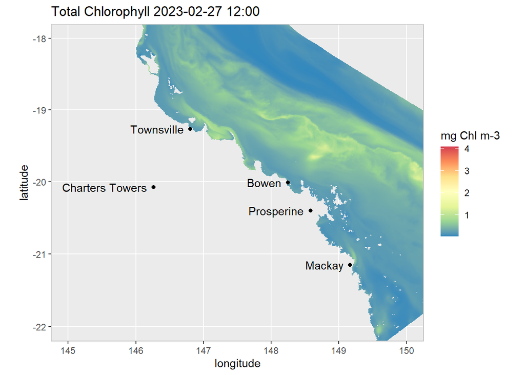

```r
map_ereefs(var_name = "Chl_a_sum", target_date = c(2023, 2, 28), input_file = "https://dapds00.nci.org.au/thredds/dodsC/fx3/GBR1_H2p0_B3p2_Cfur_Dnrt.ncml",
  scale_col = "spectral", Land_map = TRUE, box_bounds = c(145, 150, -22, -18))
```

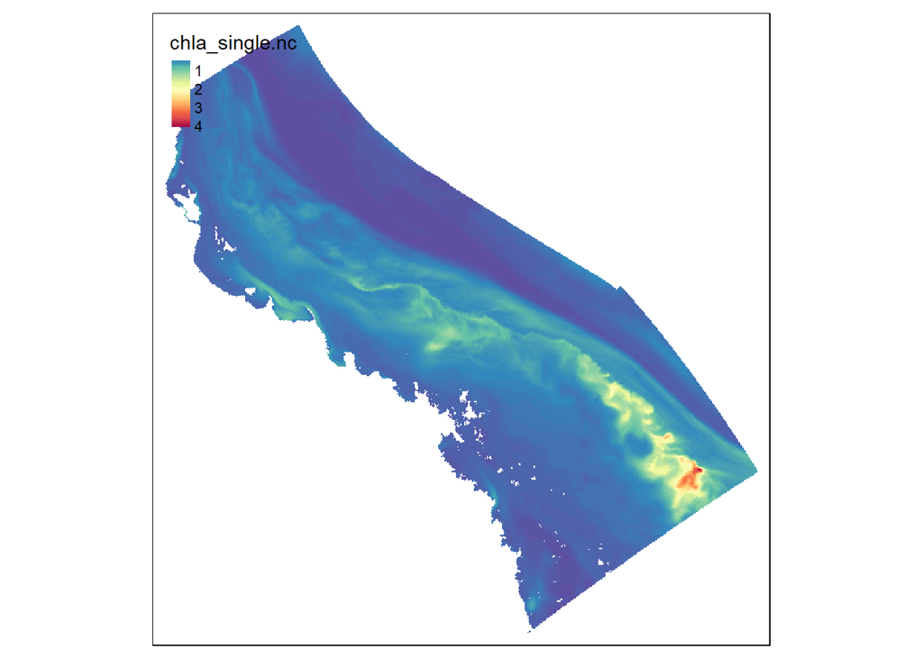

```r
tm_shape(r) + tm_raster(style = "cont", palette = "-Spectral")
```

# 5 Method 3: AIMS’ linear grid datasets

The core issue with CSIRO’s ereefs datasets is that they are plotted on a curvilinear grid that must then be converted to a linear grid. This conversion takes a lot of time and understanding. To circumvent this road block AIMS also provide a pre-transformed version of the data. This transformed version is much easier to handle and understand. However the key issue with this data is the time delay - currently AIMS’ linear gridded datasets are only available up to 2019 - 4 years behind the datasets that are available in the curvilinear format. For this reason the AIMS linear grid method is not a viable method, however the workflow is still demonstrated below as a record of the trial.

## 5.1 Download Total Nitrogen (TN) Data

In the below code chunk we download TN data for the N3 region.

```r
#read in the northern three spatial files and reduce down to only the components we need
n3_marine_region <- st_read(here("data/n3_region-builder/n3_region.gpkg")) |> filter(environment == "Marine")
#create a bounding box of our study area for downloading
n3_bbox <- st_bbox(n3_marine_region)

#create the file prefix for the path to download
file_prefix <- "https://thredds.ereefs.aims.gov.au/thredds/dodsC/s3://aims-ereefs-public-prod/derived/ncaggregate/ereefs/GBR4_H2p0_B3p1_Cq3b_Dhnd/monthly-monthly/EREEFS_AIMS-CSIRO_GBR4_H2p0_B3p1_Cq3b_Dhnd_bgc_monthly-monthly-"

#pick a date
date_vector <- "2018-01"

#open the connection to the file
file_path <- glue("{file_prefix}{date_vector}.nc")
server_file <- open.nc(file_path)

#read the lat and long of the file we have connected with
lon <- var.get.nc(server_file, "longitude")
lat <- var.get.nc(server_file, "latitude")

#determine the minimum and maximum indices for each of our lats and longs
lon_start <- which.min(abs(lon - n3_bbox[1] + 0.1)) #find the index within "lon" that is closest (but more than) n3_bbox[1]
lat_start <- which.min(abs(lat - n3_bbox[2] + 0.1))
lon_count <- which.min(abs(lon - n3_bbox[3] - 0.1)) - lon_start #find the index for the last lon we want to get
lat_count <- which.min(abs(lat - n3_bbox[4] - 0.1)) - lat_start

#create the start and count vectors for how much data we are going to select
start_vector <- c(lon_start, lat_start, 17, 1) #order is: long, lat, depth, time.
count_vector <- c(lon_count, lat_count, 1, 1) #we only want to vary long and lat and keep everything else consistent

#get the specific variable and save it as a matrix
file_matrix <- var.get.nc(ncfile = server_file, variable = "TN",
                          start = start_vector, count = count_vector)

#close the connection to the file
close.nc(server_file)

#calculate the extent based on the lat and long (xmin, ymin, xmax, ymax)
rast_extent <- ext(c(min(lon[lon_start]), min(lat[lat_start]),
                   max(lon[lon_start+lon_count]), max(lat[lat_start+lat_count])), xy = T)

#convert the matrix into a SpatRaster
tn <- file_matrix |> terra::t() |> rast(extent = rast_extent, crs = proj_crs) |> flip("vertical")

#update the time and name components of the raster
time(tn) <- date(glue("{date_vector}-01"))
names(tn) <- glue("TN_{date_vector}")
```

Here’s how that looks:

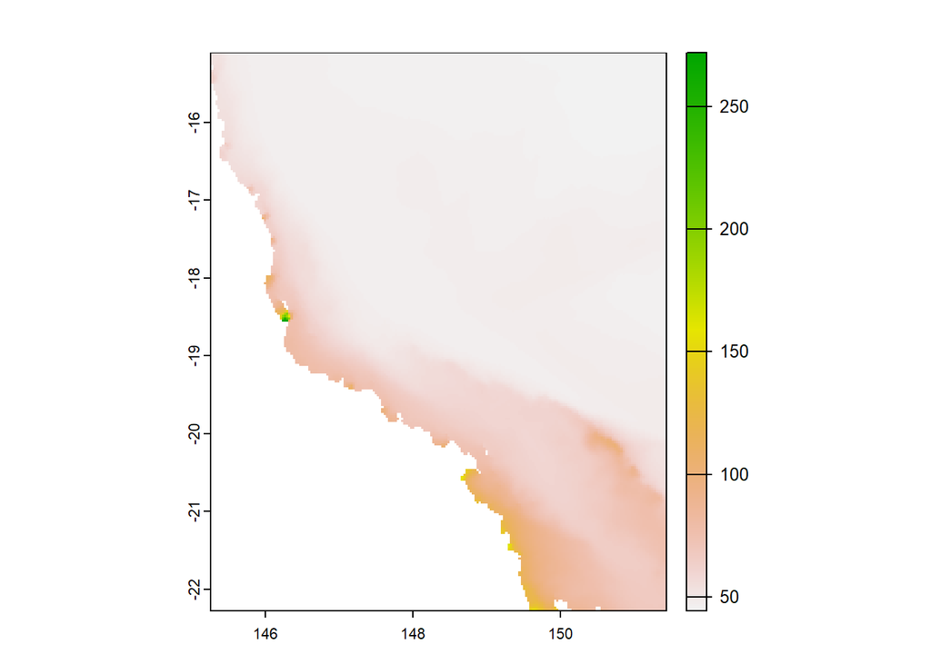

```r
#view
plot(tn)
```

## 5.2 Analyse Data

Here we begin the data analysis component, first by creating a “Key Table” (a table that contains all layer names, dates, and associated info (e.g. financial year)). We can then utilize this table to calculate some summary statistics. These statistics and/or the raw cell values can then be used to calculate a score and grade for each variable.

### 5.2.1 Average Monthly Value

The first on the list is to calculate a monthly value for each variable for each offshore zone in each of the regions. The code chunk below achieves this by using exactextract().

```r
#select only the offshore zone
n3_offshore <- n3_marine_region |> filter(basin_or_zone == "Offshore")

#get mean from all layers (make sure layers are monthly)
tn_mean_region <- tibble(exactextractr::exact_extract(tn, n3_offshore, fun = "mean", append_cols = T))
#fix column names
names(tn_mean_region) <- sub('mean.', '', names(tn_mean_region))

#add units
tn_mean_region <- tn_mean_region |> mutate(units = "mg N m-3")

#pivot data, round values
tn_mean_region <- pivot_longer(tn_mean_region, cols = 7:ncol(tn_mean_region),
                            names_to = "layer_name", values_to = "monthly_mean")
```

Additional calculations could then be run such as annual means etc, after downloading extra layers.

## 5.3 Visualise Data

We can also visualise.

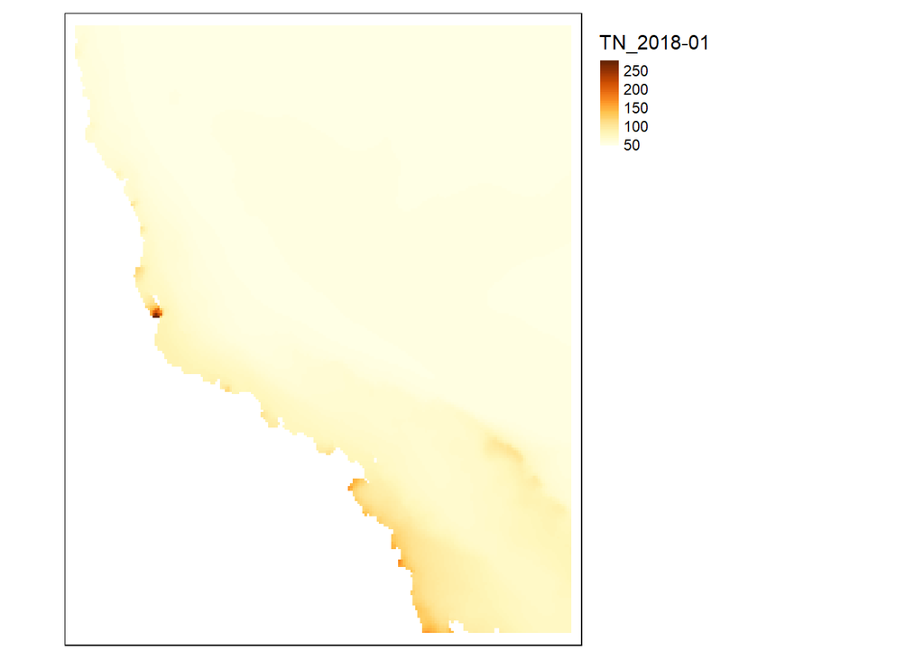

```r
tm_shape(tn) +
  tm_raster(style = "cont", legend.reverse = T) +
  tm_layout(legend.outside = T)
```

# 6 Method 4: stars package

As mentioned above, the stars method is the optimal method of ereefs data handling. The stars method has been provided its own script entirely.

# 7 Session Info

Below is the session info at the time of rendering this script. Of greatest importance is to note the R version, and the “other attached packages” as these are the most significant drivers of success/failure. It is also good to check the “attached base packages” and “loaded via a namespace” packages as well. To check your session info use `sessionInfo()`.

[session information not shown]

## Footnotes

[^1]: This was identified as the optimal method